# HOW TO CITE

Hellmuth, Franziska (2019), NEGI-2019 course Report: Evaluation of CMIP6 against ground-based observations and MERRA2, University of Oslo, franziska.hellmuth@geo.uio.no

# Intercomparison between CMIP6 model, MERRA2 satellite-retrieved reanalysis data and AERONET of aerosol optical depth

**Franziska Hellmuth**

*NEGI course 2019 - eScience for linking Arctic measurements and modeling*

**Group assistants: Paul Glantz, Ksenia Tabakova, Jonas Gliss**

# Abstract

# Introduction

It has long been known that the Arctic region is particular sensitive to global warming (Collins et al., 2013). In a warming climate will the sea ice decrease and larger areas of open water will follow an increas in organic aerosol uptake. Aerosols (organic or anthropogenic) can affect the Earth climate through interaction with solar radiation and clouds. Continuous AOD measurements from Sunphotometers distributed over the globe can give an idea about the distribution of aerosols in the atmosphere. This measurements are sparse in the Arctic and represent the AOD distribution only for a small area. With the lanch of satellites it is possible to retrieve global estimates of aerosol optical depth (AOD). Cloud free daily data can be used to reanalyse the AOD in a finer grid scale and use it to validate global climate model performance to predict the changing climate more accurately. Glantz et al., 2014 analysed the AOD in the Svalbard area. They compared Moderate Resolution Imaging Spectroradiometer (MODIS) Aqua retrievals of AOD to Sunphotometer measurements from Svalbard. The study showed that the the Svalbard region undergoes a seasonal cycle with higher AOD during spring and a low AOD during summer. The remote sensing data is then used to examine the AOD generation of global climate models, represented in the Coupled Model Intercomparison Project 5 (CMIP5). The results showed an underestimation of AOD during spring and overestimation during summer by the CMIP5 models against the remote sensing data on the preiod 1980-2004.

In the presented study nine years of Modern-Era Retrospective analysis for Research and Applications 2 (MERRA2) satellite reanalysis is compared to ground-based Sunphotometer AOD measurements in the Arctic. Thereafter, are climate model simulations from CMIP6 examined in comparison to MERRA2 satellite reanalysis over 34 years. The following questions are addressed:

1. How representative are MERRA2 satellite reanalysis in comparison to the ground-based AOD observations in the Arctic?
2. How accurately do global climate model simulate the seasonal cycle of AOD for the Arctic?

Section 2.1 and Section 2.2 contains the code to read the observational data from the Sunphotmeters and the MERRA2 satellite reanalysis in the Arctic region, respectively. Section 2.3 consists of the code for finding the AOD at 550nm in the CMIP6 models and their ensembles.

# Ground-based, satellite reanalysis and CMIP model data

Global climate models are essential to study future climate changes of aerosols and clouds.  
Aerosol optical depth (AOD) at 550nm from Sunphotometer measurements from Aerosol Robotic Network (AERONET) are used as reference to satellite retrieved reanalysis and the global climate models. AOD satellite reanalysis data from the MERRA2 are used with analogous aerosol properties from Historical Phase 6 of the CMIP6 model runs. The CMIP6 includes 33 participating model groups (Eyring et al., 2016) and data is available through the CMIP6 search interface https://esgf-data.dkrz.de/search/cmip6-dkrz/. Of these 33 models, I focus on ten models to evaluate the AOD. The model specifications can be found in **Table 1**.

**Table 1:** List of CMIP6 models, AERONET Sunphotometer and MERRA2 AOD data used in this study with References.

[output not shown]

```python
### Create dask cluster to work parallel in large datasets

from dask.distributed import Client
client = Client(n_workers=2, threads_per_worker=2, memory_limit='2GB',processes=False)
client
chunks={
    'time' : 10,
}
client
```

Client

- **Scheduler:** inproc://10.11.155.234/3052/1

- **Dashboard:** http://10.11.155.234/3052/1:8787/status

Cluster

- **Workers:** 2

- **Cores:** 4

- **Memory:** 4.00 GB

```python
# supress warnings
import warnings
warnings.filterwarnings('ignore')

# Import packages
from imports import (xr, plt, np, ccrs, sns, pd, pya, fct, )
from glob import (glob)
pya.change_verbosity('critical', log=pya.const.print_log) # don't output warnings
pya.__version__


# reload imports
%load_ext autoreload
%autoreload 2
#%reload_ext autoreload

# Plotting cosmetics
fct.plot_style()
```

```python
### Define data location for AERONET Sunphotometer, MERRA2 and CMIP6

pyaero_path = 'shared-ns1000k/inputs/pyaerocom-testdata'
merra_path  = 'data_MERRA2/'
cmip_path   = 'shared-cmip6-for-ns1000k/historical/'
```

## AERONET Sunphotometer

I want to read in the AOD measrued at 550nm by the Sunphotometer for the Arctic region. The Arctic region is defined as latitudes larger than 66$^\circ$ N. I will transform it to `xarry`, since its functionality will make it easier for me to handle the data. Plotting is similar as in `pandas`. The function `read_aerocom_return_xarray_median_std` will help me to read in the ungridded data with [Pyaerocom](https://pyaerocom.met.no/). The output will give the AOD at 550nm, the longitude and latitude, median and standard deviation for the Arctic stations. Most of the stations had a course data coverage therfore did I decide to use the years 2006 to 2014.

```python
# Pick out the stations for the Arctic
# Lat in decimal form
lower_lat = 66.; lower_lon = -180.
upper_lat = 90.; upper_lon = 180.
# Pick out the years for analysis
starty = '2006'
endy   = '2014'

# AeroCom AOD values from Arctic stations
aeronet_arctic = fct.read_aerocom_return_xarray_median_std(pyaero_path, lower_lat, upper_lat, starty, endy)

# only use AERONET stations which have data for starty and endy
valid_aeronet_arctic = {}
for station_name in aeronet_arctic.keys():
    if len(aeronet_arctic[station_name]['median_'+starty+endy]) <= 0 or \
       len(aeronet_arctic[station_name]['std_'+starty+endy]) <= 0:
        continue
    else:
        valid_aeronet_arctic[station_name] = aeronet_arctic[station_name]
        print(station_name,
              valid_aeronet_arctic[station_name]['latitude'],
              valid_aeronet_arctic[station_name]['longitude'])
```

```
ARM_Oliktok_AK 70.4995 -149.88
Abisko 68.35000000000001 18.817000000000004
Andenes 69.27833299999998 16.008611
Barrow 71.31219999999998 -156.665
Hornsund 77.00148000000002 15.540279999999997
Ittoqqortoormiit 70.48479999999999 -21.9512
Kangerlussuaq 66.99580000000003 -50.6214
Ny_Alesund 78.929433 11.86085
OPAL 79.990278 -85.939167
PEARL 80.053611 -86.41694400000002
Resolute_Bay 74.70512299999999 -94.96940900000004
Sodankyla 67.36662 26.629569999999998
Thule 76.516102 -68.769001
Tiksi 71.58691699999999 128.921417
```

## MERRA2

In Section 3.1 the MERRA2 satellite reanalysis is evaluated against the ground-based AOD measurements to know how representative MERRA2 is for the Arctic stations. For this we used [NASAs GIOVANNI interface](https://giovanni.gsfc.nasa.gov/giovanni/) to retrieve the monthly AOD averages for the stations. We chose the gridbox closes to the latitude and longitude of the AERONET stations in the Arctic.

The function `read_merra2_return_xarray_median_std` will read in the `.csv` files according to the station latitude and longitude from AERONET and returns a `xarray`. A monthly median and standard deviation is created for the AOD values to analyse the seasonal variability in **Fig. 2** for 2006-2014.

```python
# MERRA2 AOD values from Arctic stations
_mfile = merra_path + 'g4.areaAvgTimeSeries.M2IMNXGAS_5_12_4_AODANA.2006'
merra_arctic = fct.read_merra2_return_xarray_median_std(aeronet_arctic, _mfile, starty, endy)
```

MERRA2 satellite reananlysis has monthly averages of AOD from 1980. This values will be used to evaluate the CMIP6 historical simulations for the Arctic region (latitudes larger than 66$^\circ$N). The historical simulations help to evaluate the performance of the models against observations and futurer predictions. The function `read_merra2` will return a `pandas` DataFrame.

```python
# Arctic 180W,66N - 180E,90N (1980-2014)
_mfile = merra_path+ 'g4.areaAvgTimeSeries.M2IMNXGAS_5_12_4_AODANA.19800101-20141231.180W_66N_180E_90N.csv'
merra_hist = fct.read_merra2(_mfile, 'mean_M2IMNXGAS_5_12_4_AODANA', 'M_Arctic' )
merra_hist.head()
```

| time | M_Arctic |
| --- | --- |
| 1980-01-01 | 0.104969 |
| 1980-02-01 | 0.103549 |
| 1980-03-01 | 0.110453 |
| 1980-04-01 | 0.109904 |
| 1980-05-01 | 0.109821 |

I also started analysing a region west of Svalbard against the ground-based station **Hornsund** . Therfore will this region be added to the `pandas.DataFrame`.

```python
# Nordic Sea, west of Svalbard 15W,75N - 10E,82N
_mfile = merra_path+ 'g4.areaAvgTimeSeries.M2IMNXGAS_5_12_4_AODANA.19800101-20141231.15W_75N_10E_82N.csv'

merra_hist.insert(loc=1,
                  column='M_Svalbard',
                  value=fct.read_merra2(_mfile, 'mean_M2IMNXGAS_5_12_4_AODANA', 'M_Svalbard' )['M_Svalbard'].values)
merra_hist.head()
```

| time | M_Arctic | M_Svalbard |
| --- | --- | --- |
| 1980-01-01 | 0.104969 | 0.116562 |
| 1980-02-01 | 0.103549 | 0.093377 |
| 1980-03-01 | 0.110453 | 0.147553 |
| 1980-04-01 | 0.109904 | 0.123854 |
| 1980-05-01 | 0.109821 | 0.119110 |

I transfered the `pandas.DataFrame` to `xarray` which are within a dictonary to make the plotting easier later on.

```python
# add to merra arctic xarray stations the Arctic area(180W-180E,66-90N) and
# the Svalbard area (15W-10E,75-82N)

merra_arctic['M_Arctic'] = {}
merra_arctic['M_Svalbard'] = {}
merra_arctic['M_Arctic']['od550aer'] = xr.DataArray(merra_hist['M_Arctic'], dims=['time',])
merra_arctic['M_Svalbard']['od550aer'] = xr.DataArray(merra_hist['M_Svalbard'], dims=['time',])
```

```python
# median and std for 2006-2014
merra_arctic['M_Arctic'] = fct.calc_xarray_median_std(merra_arctic, 'M_Arctic', '2006', '2014')
# median and std for 1980-2014
merra_arctic['M_Arctic'] = fct.calc_xarray_median_std(merra_arctic, 'M_Arctic', '1980', '2014')
```

```python
# find zonal csv files
fn_list = glob(merra_path+'g4.zonalMean.M2IMNXGAS_5_12_4_AODANA.*')
fn_list.sort()
fn_list

# read zonal files and assign to dictonary with xarray
_dir = merra_path+'g4.zonalMean.M2IMNXGAS_5_12_4_AODANA.*'
merra_zonal = fct.read_merra2_zonal(_dir)
```

Information about the correlation between MERRA2 and the AERONET stations will be helpful to validate how representative the MERRA2 reanalysis is compared to the Arctic stations. `calc_statistic` uses a function from [Pyaerocom](https://pyaerocom.met.no/), namely `pyaerocom.mathutils.calc_statistics`. It will return all necessary values to analyse the correlation.

```python
stat_arctic_st, stat_arctic_merra = fct.calc_statistic(aeronet_arctic, merra_arctic, '2006', '2014')
```

## CMIP6

I did not know which CMIP6 historical simulations contain the AOD at 550nm in the `shared-cmip6-for-ns1000k` folder. Hence I want to find all models saved in the folder. This is done by using the `glob()` function, provided by the python glob package.

```python
_hmd = glob(cmip_path+'/*')
cmip6_model = []       # find all model names of historical runs
for i in range(len(_hmd)):
    cmip6_model.append(_hmd[i][len(cmip_path):])
print('CMIP6 models containing AOD at 550nm')
print(*cmip6_model, sep = ',')
```

[output not shown]

After returning all CMIP models I will now search in the subfolders containing the AOD at 550nm. For each model, monthly data from 1980 - 2014 is chosen to overlap with MERRA2. There are several ensembles and run variations available. I use the `r1i1p1f1`, `r1i1p2f1`, `r1i1p1f2` esnemble member, as it was available on the `shared-cmip6-for-ns1000k` folder.

Read all CMIP6 historical simulation including the AOD at 550nm (1980-2014) with `read_all_cmip6_od550aer`. The function will return a `dictionary` containing the model name and ensemble member. The longitude will be shifted from originally 0-360$^\circ$ to 180$^\circ$W - 180$^\circ$E. Areacella values are added to the `xarray` to later calculate the weighted averages with the `masked_average` function (provided by assistants on [NEGI-2019 webpage](https://nordicesmhub.github.io/NEGI-Abisko-2019/training/Example_model_global_arctic_average.html)).

```python
cmip = fct.read_all_cmip6_od550aer(cmip6_model,cmip_path,chunks,
                                   lower_lat, upper_lat,
                                   lower_lon, upper_lon, '1980', '2014')
```

In this step the weighted avarages for each CMIP6 model and ensemble member is performed for chosen years and chosen region. First I will evaluate the CMIP6 models in the Arctic region (latitude larger than 66$^\circ$N) between 1980 and 2014. The function `calc_weighted_av_median_std` will add to the existing `cmip` dictionary the weighted average for AOD as well as the monthly median and standard deviation for the chosen time period.

```python
starty='1980'; endy='2014'

# calculate weighted mean, monthly mean and standard deviation for the Arctic
for model in cmip.keys():
    for rea in cmip[model].keys():
        cmip[model][rea] = fct.calc_weighted_av_median_std(cmip[model][rea],
                                                           starty, endy,
                                                           model,
                                                           cmip[model][rea]['lat'] <= (lower_lat-5),
                                                           ['lat', 'lon'],
                                                           lower_lat, upper_lat,
                                                           lower_lon, upper_lon,
                                       )
# only use cmip data which have data for starty and endy and average to a monthly mean
valid_cmip={}
for model in cmip.keys():
    valid_cmip[model] = {}
    for rea in cmip[model].keys():
        try:
            cmip[model][rea]['median_'+starty+endy]
            valid_cmip[model][rea] = cmip[model][rea]
        except KeyError:
            continue
```

```
no areacella data:  UKESM1-0-LL
no areacella data:  BCC-ESM1
no areacella data:  HadGEM3-GC31-LL
no areacella data:  CNRM-ESM2-1
```

```python
for model in cmip.keys():
    for rea in cmip[model].keys():
        # for 1980-1989
        cmip[model][rea]  = fct.calc_weighted_av_median_std(cmip[model][rea],
                                                            '1980','1989',
                                                            model,
                                                            dim=['lon'])
        # for 1990-1999
        cmip[model][rea]  = fct.calc_weighted_av_median_std(cmip[model][rea],
                                                            '1990','1999',
                                                            model,
                                                            dim=['lon'])
        # for 2000-2009
        cmip[model][rea]  = fct.calc_weighted_av_median_std(cmip[model][rea],
                                                            '2000','2009',
                                                            model,
                                                            dim=['lon'])
```

```
no areacella data:  UKESM1-0-LL
no areacella data:  UKESM1-0-LL
no areacella data:  UKESM1-0-LL
no areacella data:  BCC-ESM1
no areacella data:  BCC-ESM1
no areacella data:  BCC-ESM1
no areacella data:  HadGEM3-GC31-LL
no areacella data:  HadGEM3-GC31-LL
no areacella data:  HadGEM3-GC31-LL
no areacella data:  CNRM-ESM2-1
no areacella data:  CNRM-ESM2-1
no areacella data:  CNRM-ESM2-1
```

# Results and Discussion

As mentioned before will CMIP6 historical simulations be evaluated against the satellite reanalysis product MERRA2. To have confidence in the analysis the MERRA2 AODs are compared to the AERONET ground-based stations Section 3.1. With a warming climate the areas of open water will increase in the Arctic. Related to this will the sea-salt and organic aerosol discharge increase (Glantz et al., 2014). The Arctic undergoes a seasonal cycle of AOD. During the Arctic summer new particles formation occurs due to higher insolation $\rightarrow$ higher levels of OH and more efficient precipitation cleansing. Section 3.2 will evaluate the CMIP6 seasonal cycle in the Arctic region between 1980 and 2014. A zonal assesement of CMIP6 models will then give an insight in how the models simulated the past three decades in a 'global' scale (Section 3.3).

## MERRA2 evaluation

Seasonal AOD from the AERONET stations are compared to the MERRA2 reanalysis from 2006 to 2014 to determine how representative the fine resolution MERRA2 data is for the Arctic region.

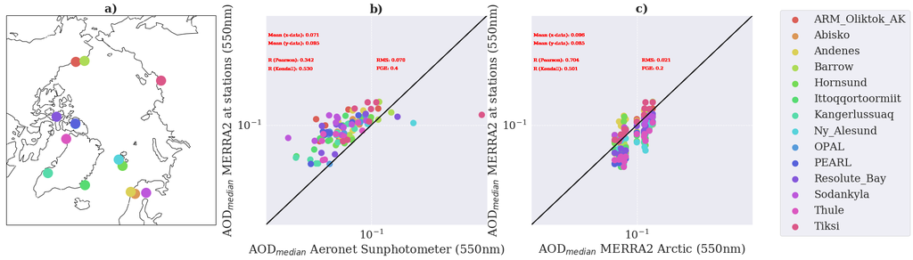

```python
# Figure
starty = '2006'; endy = '2014'
fig = plt.figure(figsize=[28,8])
ax1 = fig.add_subplot(131,
                      projection= ccrs.AzimuthalEquidistant(central_longitude=0,
                                                            central_latitude=90,))

ax2 = fig.add_subplot(132)
ax3 = fig.add_subplot(133)
for station_name, i  in zip(valid_aeronet_arctic.keys(), range(len(valid_aeronet_arctic))):

#    if len(aeronet_arctic[station_name]['median_'+starty+endy]) <= 0 or len(aeronet_arctic[station_name]['std_'+starty+endy]) <=0:
 #       continue
  #  else:
        # Plot stations on map
        ax1.plot(valid_aeronet_arctic[station_name]['longitude'],
                 valid_aeronet_arctic[station_name]['latitude'],
                 'o',
                 color = sns.color_palette("hls",len(valid_aeronet_arctic))[i],
                 markersize=20,
                 transform=ccrs.PlateCarree(),
                 label=station_name)
        # Sunphotometer vs MERRA2 at stations
        fct.plt_scatter(aeronet_arctic[station_name]['median_'+starty+endy],
                        merra_arctic[station_name]['median_'+starty+endy][int(aeronet_arctic[station_name]['median_'+starty+endy][0].month-1):int(aeronet_arctic[station_name]['median_'+starty+endy][-1].month)],
                        [0.015,0.8],[0.015,0.8],
                        'AOD$_{median}$ Aeronet Sunphotometer (550nm)', 'AOD$_{median}$ MERRA2 at stations (550nm)',
                        stat_arctic_st,
                        'b)', ax2, sns.color_palette("hls",len(valid_aeronet_arctic))[i])
        # MERRA2 Arctic median vs MERRA2 at stations
        fct.plt_scatter(merra_arctic['M_Arctic']['median_'+starty+endy],
                        merra_arctic[station_name]['median_'+starty+endy],
                        [0.015,0.8],[0.015,0.8],
                        'AOD$_{median}$ MERRA2 Arctic (550nm)', 'AOD$_{median}$ MERRA2 at stations (550nm)',
                        stat_arctic_merra,
                        'c)', ax3, sns.color_palette("hls",len(valid_aeronet_arctic))[i])

# Limit the map degrees latitude
ax1.set_extent([-180, 180, 90, 60], ccrs.PlateCarree())
ax1.coastlines()
ax1.gridlines()
ax1.set_title('a)', fontweight='bold')



# Legend
ax3.legend(bbox_to_anchor=(1.1, 1.05));
```

**Fig. 1:** Monthly median for AOD at 550nm for 2006-2014. **a)** Aeronet stations above 66$^\circ$N. **b)**Aeronet Sunphotometer vs. MERRA2 for Arctic stations in corresponding colors. **c)** area averaged AOD for the Arctic region (180W-180E, 66-90N) vs. MERRA2 AOD at station gridbox.

In **Fig. 1a)** we see valid measurement stations for AOD in the Arctic region between 2006 and 2014. The monthly medians of AOD at the stations are presented in **Fig. 1b)**. MERRA2 comparison on how well the AOD at the stations is in comparison to the Arctic area averaged AOD is shown in **Fig. 1c)**. In **Fig. 1b)** is the linear Pearson correlation coefficient for for all stations +0.3, meaning the data points are varying from the best fit and having a medium correlation. We also see, that MERRA2 overestimates the monthly mean AOD. With this in mind we compare the two MERRA2 data sets **Fig. 1c)**. The correlation is large (R$_{Pearson}$ = 0.7), but not best. However this result will give as later some confidence when we are analysing the CMIP6 historical simulations.

We want to see further how well the MERRA2 Arctic mean compares to the AERONET ground-based measurements, in particular the seasonal variation of AOD. Therefore monthly means for each station are plotted together with the MERRA2 data described in Section 2.2.

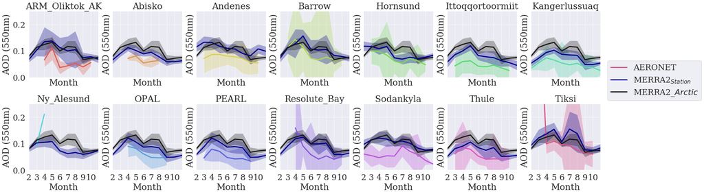

```python
# Figure
fig, axsm = plt.subplots(2,7, sharex='all', sharey='all',
                         figsize = [28,8])
axs = axsm.flatten()
for station_name, i  in zip(valid_aeronet_arctic.keys(), range(len(valid_aeronet_arctic))):

        # plot aeronet monthly median at station
        fct.plt_seasonal_model_ensemble(valid_aeronet_arctic[station_name], axs[i],
                                        starty, endy,
                                        sns.color_palette("hls",len(valid_aeronet_arctic))[i])
        # plot MERRA2 monthly median at station
        fct.plt_seasonal_model_ensemble(merra_arctic[station_name], axs[i],
                                        starty, endy,
                                        'darkblue')
        # plot MERRA monthly median for Arctic
        fct.plt_seasonal_model_ensemble(merra_arctic['M_Arctic'], axs[i],
                                        starty, endy,
                                        'k')

        axs[i].set_title(station_name)
        axs[i].set_xlim([2,11])
        axs[i].set_ylim([0, 0.25])
        axs[i].set_xticks(np.arange(2,11))
        axs[i].set_ylabel('AOD (550nm)')
        axs[i].set_xlabel('Month')


axs[len(valid_aeronet_arctic)-1].legend(['AERONET', 'MERRA2$_{Station}$', 'MERRA2_${Arctic}$'],
                                        bbox_to_anchor=(1.1, 1.05), loc='lower left', borderaxespad=0., fancybox=True)
plt.subplots_adjust(wspace = 0.2, hspace=0.4)
```

**Fig. 2:** Monthly median for AOD at 550nm between 2006-2014. Colored lines from the AERONET Sunphotometer at the station, blue: MERRA2 taken closest gridpoint to AERONET station, black: Arctic average.

The colored lines in **Fig. 2** represent the monthly means from the AERONET stations between 2006 and 2014. Most of the ground-based observations show a AOD peak during spring, except Andenes (Norway) and Sodankyla (Finnland). Abisko (Sweden), Barrow (Alaska), Hornsund (Svalbard) and Ittoqqortoormiit (Greenland) show a second peak during Arctic summer.

In all cases we have to keep in mind, that AOD can only be measured during Arctic summer and on cloud free days.

## CMIP6 seasonal evaluation

```python
_mm = []
_rr = []
for model in valid_cmip.keys():
    if len(valid_cmip[model].keys()) > 0:
        if len(valid_cmip[model].keys()) >=1:
            for rea in valid_cmip[model].keys():
                _mm.append(model)
                _rr.append(rea)


# Figure
starty = '1980'; endy   = '2014'
fig, ax = plt.subplots(1,figsize=[10,7])
# plot the MERRA2 seasonal cycle
fct.plt_seasonal_model_ensemble(merra_arctic['M_Arctic'], ax,  starty, endy,'k' )
# plot CMIP6 seasonal cycle
for model, rea, i in zip(_mm, _rr, range(len(_mm))):
    # print(model,rea, i)
    valid_cmip[model][rea]['median_'+starty+endy].plot(ax = ax,
                                                               label=model+'_'+rea,
                                                               color = sns.color_palette("hls",12)[i],
                                                               linewidth=3,
                                                               linestyle='--')
    ax.fill_between(valid_cmip[model][rea]['median_'+starty+endy].month,
                            valid_cmip[model][rea]['median_'+starty+endy] - valid_cmip[model][rea]['std_'+starty+endy],
                            valid_cmip[model][rea]['median_'+starty+endy] + valid_cmip[model][rea]['std_'+starty+endy],
                            alpha=0.3,
                            facecolor=sns.color_palette("hls",12)[i])

ax.set_ylabel('AOD (550nm)')
ax.set_xlabel('%s - %s' %(starty,endy) )
ax.set_xlim([1,12])
ax.set_xticks(np.arange(1,13))
ax.set_xticklabels(['January', 'February', 'March', 'April', 'May', 'June', 'July', 'August', 'September', 'October', 'November', 'December'],
                   rotation = 45)
ax.set_title(' %sW - %sE, %sN - %sN, median and $\sigma$' %(lower_lon,upper_lon,lower_lat,upper_lat))
ax.legend(bbox_to_anchor=(1.1, 1.05));
```

[output not shown]

## CMIP6 zonal evaluation

The impact of anthropogenic emission can also be seen zonally.

```python
# Figure
fig, axsm = plt.subplots(1,4, sharex = 'all', sharey='all',
                         figsize=[28,8])
axs = axsm.flatten()

for yr in ['19801989', '19901999', '20002009']:
    merra_zonal[yr]['M2IMNXGAS_5_12_4_AODANA'].plot(ax = axs[0], linewidth=3)
    axs[0].set_title('a) MERRA2', fontweight='bold')
    axs[0].set_xlabel('Latitude deg N')

    model = 'CanESM5'
    fct.plt_zonal_model_merra(axs[1], cmip[model][rea]['median_'+yr],
                          cmip[model][rea]['std_'+yr],
                              merra_zonal['20002009']['M2IMNXGAS_5_12_4_AODANA'],
                              model, sns.color_palette("hls",12)[5])
    axs[1].set_title('b) %s' %model, fontweight='bold')
    axs[1].set_xlabel('Latitude deg N')


    model = 'GFDL-ESM4'
    fct.plt_zonal_model_merra(axs[2], cmip[model][rea]['median_'+yr],
                          cmip[model][rea]['std_'+yr],
                              merra_zonal['20002009']['M2IMNXGAS_5_12_4_AODANA'],
                              model, sns.color_palette("hls",12)[6])
    axs[2].set_title('c) %s' %model, fontweight='bold')
    axs[2].set_xlabel('Latitude deg N')

    model = 'NorESM2-LM';
    rea = 'r1i1p1f1'
    fct.plt_zonal_model_merra(axs[3], cmip[model][rea]['median_'+yr],
                          cmip[model][rea]['std_'+yr],
                              merra_zonal['20002009']['M2IMNXGAS_5_12_4_AODANA'],
                              model, sns.color_palette("hls",12)[3])
    axs[3].set_title('d) %s' %model, fontweight='bold')
    axs[3].set_xlabel('Latitude deg N')


axs[0].legend(['1980 - 1989','1990 - 1999', '2000 - 2009'], loc='upper center')
axs[0].set_ylabel('AOD (550nm)')
axs[0].set_xlim([-90,90])
axs[0].set_xticks(np.arange(-90,120,30))
plt.subplots_adjust(wspace = 0.2,
                    hspace = 0.4   )
```

[output not shown]

# Summary and Conclusion

Further studies have to be carried out, especially a detailed study of AOD in NorESM to understand the high and low values above 50$^\circ$N and south.

# References

Collins, M., Knutti, R., Arblaster, J., Dufresne, J.-L., Fichefet, T., Friedlingstein, P., Gao, X., Gutowski, W.J., Johns, T., Krinner, G., Shongwe, M., Tebaldi, C., Weaver, A.J., Wehner, M., 2013. Long-term Climate Change: Projections, Commitments and Irreversibility, in: Stocker, T.F., Qin, D., Plattner, G.-K., Tignor, M., Allen, S.K., Boschung, J., Nauels, A., Xia, Y., Bex, V., Midgley, P.M. (Eds.), Climate Change 2013: The Physical Science Basis. Contribution of Working Group I to the Fifth Assessment Report of the Intergovernmental Panel on Climate Change. Cambridge University Press, Cambridge, United Kingdom and New York, NY, USA, pp. 1029–1136. https://doi.org/10.1017/CBO9781107415324.024

Eyring, V., Bony, S., Meehl, G.A., Senior, C.A., Stevens, B., Stouffer, R.J., Taylor, K.E., 2016. Overview of the Coupled Model Intercomparison Project Phase 6 (CMIP6) experimental design and organization. Geosci. Model Dev. 9, 1937–1958. https://doi.org/10.5194/gmd-9-1937-2016

Gelaro, R., McCarty, W., Suárez, M.J., Todling, R., Molod, A., Takacs, L., Randles, C.A., Darmenov, A., Bosilovich, M.G., Reichle, R., Wargan, K., Coy, L., Cullather, R., Draper, C., Akella, S., Buchard, V., Conaty, A., da Silva, A.M., Gu, W., Kim, G.-K., Koster, R., Lucchesi, R., Merkova, D., Nielsen, J.E., Partyka, G., Pawson, S., Putman, W., Rienecker, M., Schubert, S.D., Sienkiewicz, M., Zhao, B., 2017. The Modern-Era Retrospective Analysis for Research and Applications, Version 2 (MERRA-2). J. Climate 30, 5419–5454. https://doi.org/10.1175/JCLI-D-16-0758.1

Giles, D.M., Sinyuk, A., Sorokin, M.G., Schafer, J.S., Smirnov, A., Slutsker, I., Eck, T.F., Holben, B.N., Lewis, J.R., Campbell, J.R., Welton, E.J., Korkin, S.V., Lyapustin, A.I., 2019. Advancements in the Aerosol Robotic Network (AERONET) Version 3 database – automated near-real-time quality control algorithm with improved cloud screening for Sun photometer aerosol optical depth (AOD) measurements. Atmospheric Measurement Techniques 12, 169–209. https://doi.org/10.5194/amt-12-169-2019

Glantz, P., Bourassa, A., Herber, A., Iversen, T., Karlsson, J., Kirkevåg, A., Maturilli, M., Seland, Ø., Stebel, K., Struthers, H., Tesche, M., Thomason, L., 2014. Remote sensing of aerosols in the Arctic for an evaluation of global climate model simulations. Journal of Geophysical Research: Atmospheres 119, 8169–8188. https://doi.org/10.1002/2013JD021279

Golaz, J.-C., Caldwell, P.M., Roekel, L.P.V., Petersen, M.R., Tang, Q., Wolfe, J.D., Abeshu, G., Anantharaj, V., Asay‐Davis, X.S., Bader, D.C., Baldwin, S.A., Bisht, G., Bogenschutz, P.A., Branstetter, M., Brunke, M.A., Brus, S.R., Burrows, S.M., Cameron‐Smith, P.J., Donahue, A.S., Deakin, M., Easter, R.C., Evans, K.J., Feng, Y., Flanner, M., Foucar, J.G., Fyke, J.G., Griffin, B.M., Hannay, C., Harrop, B.E., Hoffman, M.J., Hunke, E.C., Jacob, R.L., Jacobsen, D.W., Jeffery, N., Jones, P.W., Keen, N.D., Klein, S.A., Larson, V.E., Leung, L.R., Li, H.-Y., Lin, W., Lipscomb, W.H., Ma, P.-L., Mahajan, S., Maltrud, M.E., Mametjanov, A., McClean, J.L., McCoy, R.B., Neale, R.B., Price, S.F., Qian, Y., Rasch, P.J., Eyre, J.E.J.R., Riley, W.J., Ringler, T.D., Roberts, A.F., Roesler, E.L., Salinger, A.G., Shaheen, Z., Shi, X., Singh, B., Tang, J., Taylor, M.A., Thornton, P.E., Turner, A.K., Veneziani, M., Wan, H., Wang, H., Wang, S., Williams, D.N., Wolfram, P.J., Worley, P.H., Xie, S., Yang, Y., Yoon, J.-H., Zelinka, M.D., Zender, C.S., Zeng, X., Zhang, C., Zhang, K., Zhang, Y., Zheng, X., Zhou, T., Zhu, Q., 2019. The DOE E3SM Coupled Model Version 1: Overview and Evaluation at Standard Resolution. Journal of Advances in Modeling Earth Systems 11, 2089–2129. https://doi.org/10.1029/2018MS001603

Hajima, T., Watanabe, M., Yamamoto, A., Tatebe, H., Noguchi, M.A., Abe, M., Ohgaito, R., Ito, Akinori, Yamazaki, D., Okajima, H., Ito, Akihiko, Takata, K., Ogochi, K., Watanabe, S., Kawamiya, M., 2019. Description of the MIROC-ES2L Earth system model and evaluation of its climate–biogeochemical processes and feedbacks. Geoscientific Model Development Discussions 1–73. https://doi.org/10.5194/gmd-2019-275

Held, I.M., Guo, H., Adcroft, A., Dunne, J.P., Horowitz, L.W., Krasting, J., Shevliakova, E., Winton, M., Zhao, M., Bushuk, M., Wittenberg, A.T., Wyman, B., Xiang, B., Zhang, R., Anderson, W., Balaji, V., Donner, L., Dunne, K., Durachta, J., Gauthier, P.P.G., Ginoux, P., Golaz, J.-C., Griffies, S.M., Hallberg, R., Harris, L., Harrison, M., Hurlin, W., John, J., Lin, P., Lin, S.-J., Malyshev, S., Menzel, R., Milly, P.C.D., Ming, Y., Naik, V., Paynter, D., Paulot, F., Ramaswamy, V., Reichl, B., Robinson, T., Rosati, A., Seman, C., Silvers, L., Underwood, S., Zadeh, N., n.d. Structure and Performance of GFDL’s CM4.0 Climate Model. Journal of Advances in Modeling Earth Systems 0. https://doi.org/10.1029/2019MS001829

Kirkevåg, A., Grini, A., Olivié, D., Seland, Ø., Alterskjær, K., Hummel, M., Karset, I.H.H., Lewinschal, A., Liu, X., Makkonen, R., Bethke, I., Griesfeller, J., Schulz, M., Iversen, T., 2018. A production-tagged aerosol module for Earth system models, OsloAero5.3 – extensions and updates for CAM5.3-Oslo. Geosci. Model Dev. 11, 3945–3982. https://doi.org/10.5194/gmd-11-3945-2018

Swart, N.C., Cole, J.N.S., Kharin, V.V., Lazare, M., Scinocca, J.F., Gillett, N.P., Anstey, J., Arora, V., Christian, J.R., Hanna, S., Jiao, Y., Lee, W.G., Majaess, F., Saenko, O.A., Seiler, C., Seinen, C., Shao, A., Solheim, L., Salzen, K. von, Yang, D., Winter, B., 2019. The Canadian Earth System Model version 5 (CanESM5.0.3). Geoscientific Model Development Discussions 1–68. https://doi.org/10.5194/gmd-2019-177

Voldoire, A., Saint‐Martin, D., Sénési, S., Decharme, B., Alias, A., Chevallier, M., Colin, J., Guérémy, J.-F., Michou, M., Moine, M.-P., Nabat, P., Roehrig, R., Mélia, D.S. y, Séférian, R., Valcke, S., Beau, I., Belamari, S., Berthet, S., Cassou, C., Cattiaux, J., Deshayes, J., Douville, H., Ethé, C., Franchistéguy, L., Geoffroy, O., Lévy, C., Madec, G., Meurdesoif, Y., Msadek, R., Ribes, A., Sanchez‐Gomez, E., Terray, L., Waldman, R., 2019. Evaluation of CMIP6 DECK Experiments With CNRM-CM6-1. Journal of Advances in Modeling Earth Systems 11, 2177–2213. https://doi.org/10.1029/2019MS001683

```python
!jupyter nbconvert --to html --template ./clean_output.tpl franzihe_area_averaged_AOD_V2.ipynb
```

```python
!jupyter nbconvert --to md --template ./clean_output.tpl franzihe_area_averaged_AOD_V2.ipynb
```